# Sentiment Analysis with Trump Tweets

April 7th, 2019

Josh Pause, Machine Learning Engineer, DataJenius

## Introduction

In this article we will be using R, including the tidytext and sentimentr packages, to do some natural language processing and sentiment analysis of Trump’s tweets. All of the code and data used in the creation of this article is available via our Github depository.

## Our Data

We took the last year of Trump’s tweets from the [Trump Twitter Archive](http://trumptwitterarchive.com/), from April 6th, 2018 through the evening of April 5th, 2019. This data includes 3,089 total tweets; we looked at original tweets only, and ignored his retweets.

It goes without saying that we encounter all sorts of strange characters on Twitter. More specifically, we encounter emojis, foreign languages, and lots of UTF-8 characters that can choke a standard NLP preprocessor. Most of these NLP systems are designed to work with ASCII content, which is limitted to standard English letters, numbers, and punctuation found on a standard American keyboard. When these systems encounter UTF-8 this can result in garbled punctuation appearing in your text, or a system failing to tokenize or lemmatize properly. To avoid this, we converted all tweet text to ASCII. I will refer you to [Apil Tamong’s article on the subject](https://medium.com/@apiltamang/unicode-utf-8-and-ascii-encodings-made-easy-5bfbe3a1c45a) for more information regarding UTF-8 versus ASCII.

It is also important to note that the “created_at” timestamp provided by Twitter is set in UTC time. Since Trump spends most of his time in New York, Washington D.C. and Florida, we converted all dates and times to the Eastern timezone instead.

## Psychoanalyzing the President

Given nothing but these 3,089 tweets, what can we infer about President Trump?

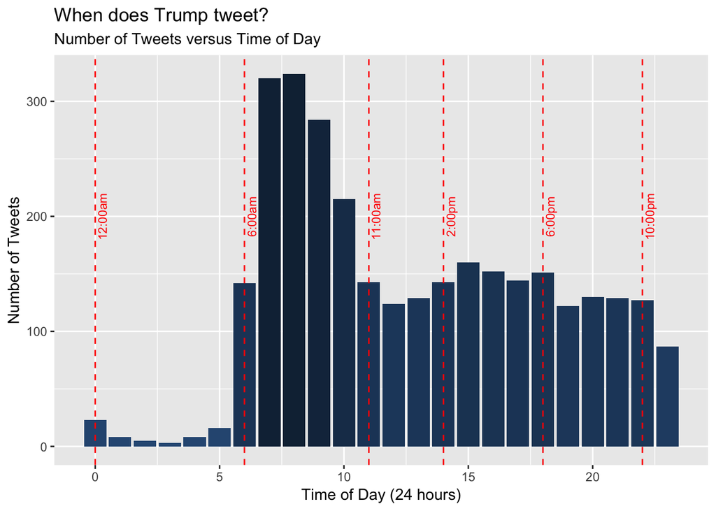

Looking at the above plot we can immediately get a feel for the President’s routine. He appears to wake up around 6:00am, and posts the majority of his tweets in the morning. Starting around 11:00am (lunch time for Trump?) he spends less time tweeting, but remains fairly active through the evening. By midnight he is usually done with Twitter for the day.

The gross majority of these tweets (more than 98%) were posted using “Twitter for iPhone”. This is not to say all of these tweets are actually written by Trump himself. It is quite possible there are social media or public relations staff handling some of these posts, but if they are, they are also using iPhones to do it most of the time.

There is an incredible amount of variance in the amount of retweets a given post by Trump receives. The least popular tweet in our data got a mere 6 retweets:

```
## [1] "The White House is running beautifully. We are making some of the greatest and most important deals in our countries history - with many more to come. Big progress!"
```

The most popular was retweeted 108,798 times:

```
## [1] "They just didn't get it but they do now! https://t.co/9T50NupkDy"
```

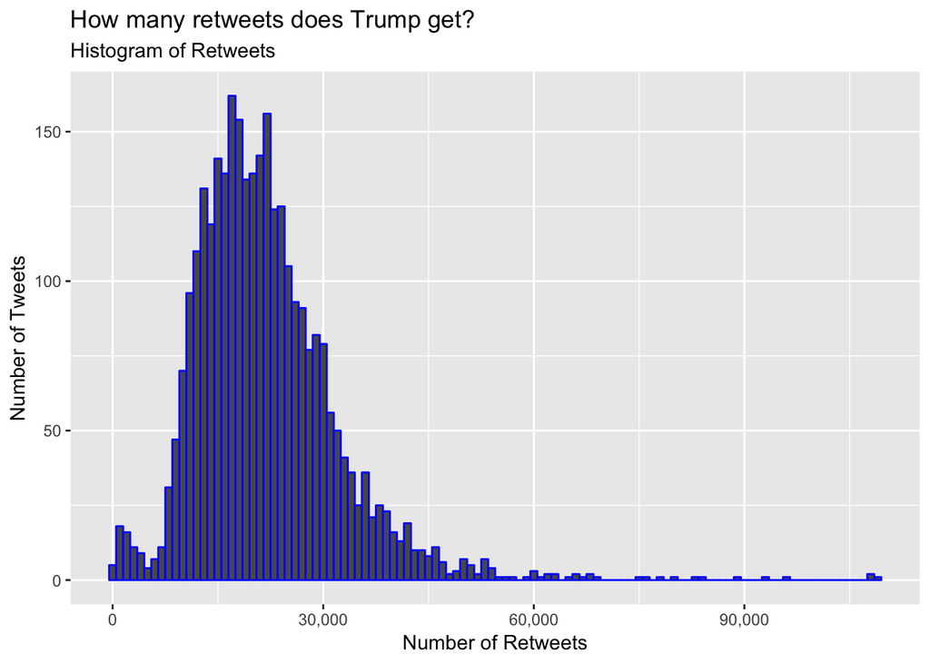

We don’t have time to read through all of these tweets manually, but that is where the real “meat and potatoes” of this data is hiding. How can we use natural language processing, and more specifically, sentiment analysis, to dig deeper?

## The NRC Lexicon

The [tidytext package](https://cran.r-project.org/web/packages/tidytext/index.html) in R comes with a series of sentiment lexicons. The [NRC lexicon](https://saifmohammad.com/WebPages/NRC-Emotion-Lexicon.htm) is one of these:

| word | sentiment |
| --- | --- |
| abacus | trust |
| abandon | fear |
| abandon | negative |
| abandon | sadness |
| abandoned | anger |
| abandoned | fear |

Words are categorized as “positive” and “negative”, but also into 8 additional emotional categories, ranging from “anger” to “joy” to “sadness”.

```
##
##        anger anticipation      disgust         fear          joy
##         1247          839         1058         1476          689
##     negative     positive      sadness     surprise        trust
##         3324         2312         1191          534         1231
```

It is also important to note that some words, including one of Trump’s favorites, are attached to several sentiments:

| word | sentiment |
| --- | --- |
| deal | anticipation |
| deal | joy |
| deal | positive |
| deal | surprise |
| deal | trust |

If we tokenize these tweets (split them up into words) and compare them to the NRC sentiment dictionary, we can count how many matching words appear in each tweet.

This allows us to view the tweet with the most “anger” words:

```
## [1] "Where's the Collusion? They made up a phony crime called Collusion and when there was no Collusion they say there was Obstruction (of a phony crime that never existed). If you FIGHT BACK or say anything bad about the Rigged Witch Hunt they scream Obstruction!"
```

Or the tweet with the most “joy” words:

```
## [1] "Thank you @WVGovernor Jim Justice for that warm introduction. Tonight it was my great honor to attend the Greenbrier Classic - Salute to Service Dinner in West Virginia! God Bless our Veterans. God Bless America - and HAPPY INDEPENDENCE DAY TO ALL! https://t.co/V35qvCN8m6"
```

Or the tweet with the most “sadness” words:

```
## [1] "At the request of many I will be reviewing the case of a U.S. Military hero Major Matt Golsteyn who is charged with murder. He could face the death penalty from our own government after he admitted to killing a Terrorist bomb maker while overseas. @PeteHegseth @FoxNews"
```

Or the tweet with the most “trust” words:

```
## [1] "Congressman Adam Smith the new Chairman of the House Armed Services Committee just stated Yes there is a provision in law that says a president can declare an emergency. It's been done a number of times. No doubt but let's get our deal done in Congress!"
```

If we look at the proportion of tweets that contain at least one word linked to each emotion, we find this:

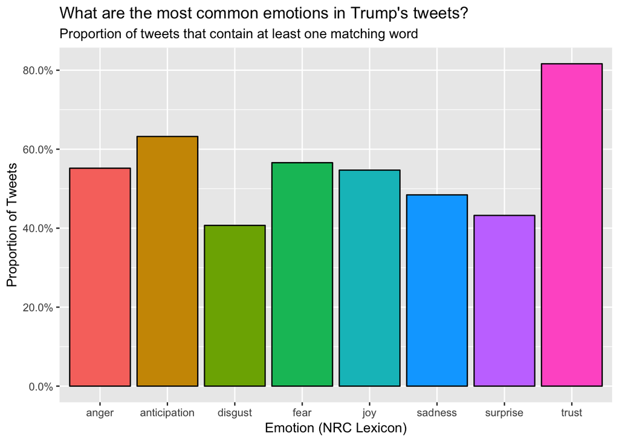

We find that roughly 82% of Trump’s tweets contain at least one word matching “trust”, followed by 63% which are associated to “anticipation”, followed by 57% which are associated with “fear”. Only 40% of Trump’s tweet contain at least one word matching to “disgust”. Remember: this can be deceptive because the same word (e.g. “deal”) can be associated to multiple emotional categories.

If we add up all emotional word matches, and look at the proportion of these matches in each emotional category, we can visualize Trump’s changing mood over time:

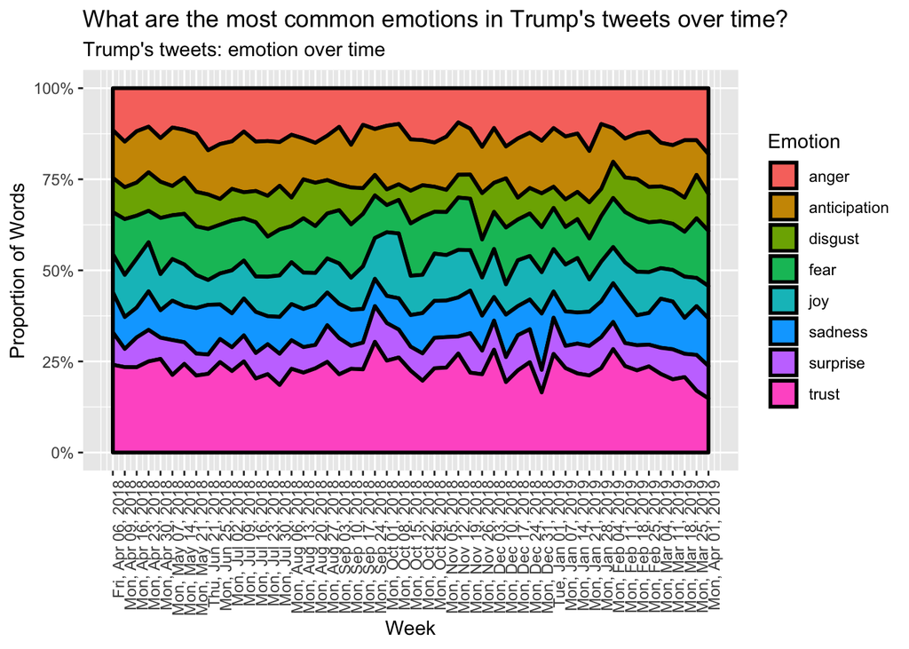

## Combining Sentiment Lexicons

In addition to all these emotional categories, the NRC lexicon provides a simplified “positive” or “negative” sentiment tag for 5,636 different words. The [AFINN Lexicon](https://github.com/fnielsen/afinn/tree/master/afinn/data) provides 2,476 words with a sentiment score of -5 (worst) to 5 (best). The Bing lexicon provides 6,788 words with a sentiment tag of “positive” or “negative”, as does the Loughran lexicon for 4,419 words. Many of these words appear across multiple lexicons:

| word | nrc | afinn | bing | loughran |
| --- | --- | --- | --- | --- |
| 2-faced | NA | NA | negative | NA |
| 2-faces | NA | NA | negative | NA |
| a+ | NA | NA | positive | NA |
| abandon | negative | -2 | NA | negative |
| abandoned | negative | -2 | NA | negative |
| abandoning | NA | NA | NA | negative |

We can combine the powers of these lexicons by assigning a numeric value for “positive” and “negative” sentiments across all of them. Using the AFINN (-5 to 5) as our basis, we can assign 2.5 for all “positive” sentiment, and -2.5 for all “negative” sentiment, and sum these scores up for each word.

| word | nrc | afinn | bing | loughran | sentiment |
| --- | --- | --- | --- | --- | --- |
| 2-faced | 0.0 | 0 | -2.5 | 0.0 | -2.5 |
| 2-faces | 0.0 | 0 | -2.5 | 0.0 | -2.5 |
| a+ | 0.0 | 0 | 2.5 | 0.0 | 2.5 |
| abandon | -2.5 | -2 | 0.0 | -2.5 | -7.0 |
| abandoned | -2.5 | -2 | 0.0 | -2.5 | -7.0 |
| abandoning | 0.0 | 0 | 0.0 | -2.5 | -2.5 |

Words that appear in more lexicons have a stronger influence on our final sentiment score, which reduces all emotion into a simplified “positive” or “negative” number. As before we can tokenize all tweets by word. This time we will score the sentiment of each individual word using the combined lexicon, and sum this to the net sentiment per tweet. In other words, does a given tweet have more positive or negative sentiment in it?

If we ignore the long tails (the tweets with extremely negative or positive sentiment), we find an approximately normal distribition, centered around a net sentiment near 5.

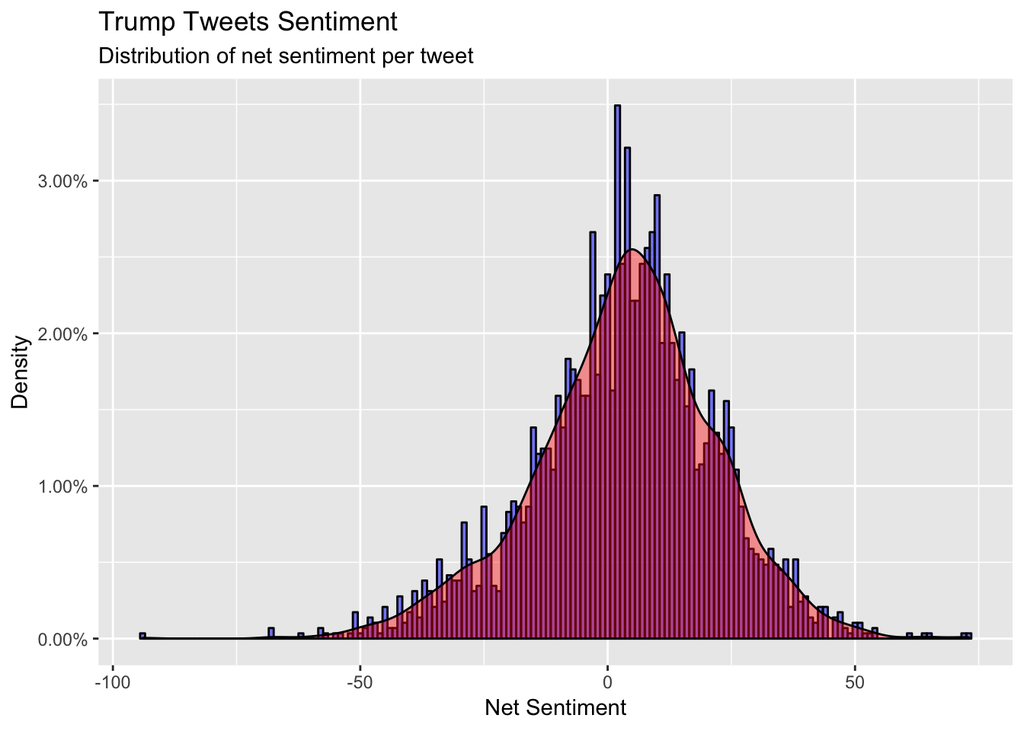

We can now look to see what proportion of tweets in a given week were “positive” (net sentiment over 0) and “negative” (all remaining tweets), and we can visualize this change over time:

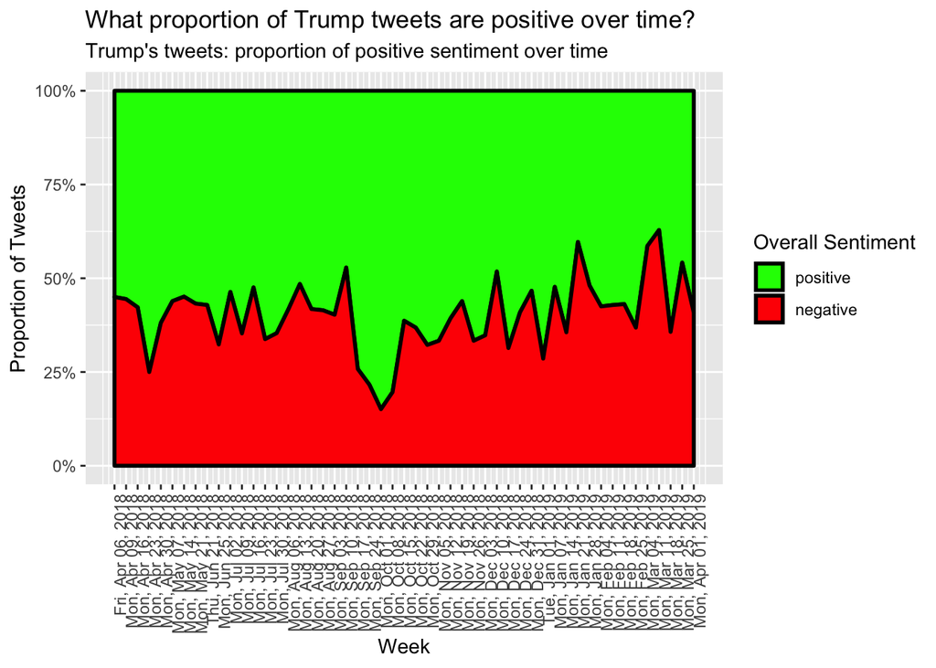

We can also visualize the net sentiment on a week-by-week basis:

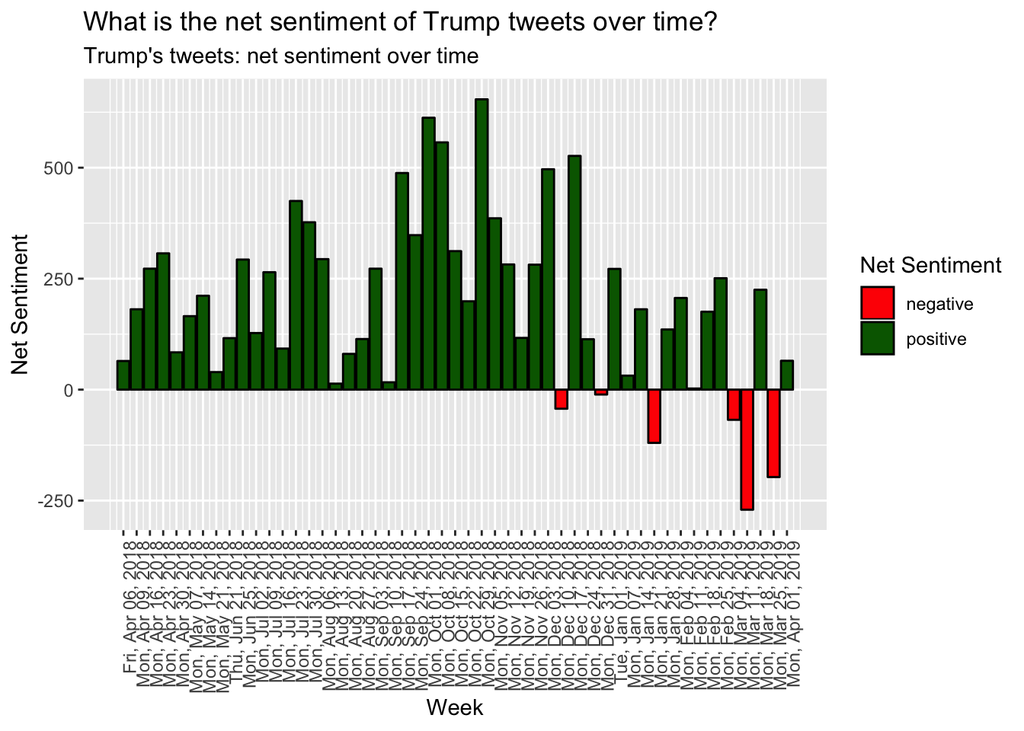

In both of the above plots we can see that Trump tweets are usually more positive than negative, but the second plot (net sentiment) considers the total amount of net tweet sentiment, making it easier to identify his “bad weeks” over the past year (the weeks where “negative” words outnumbered “positive” words).

## Understanding Drivers of Sentiment

Now that we have classified Trump’s tweets into “positive” and “negative” sentiment, we can take a closer look:

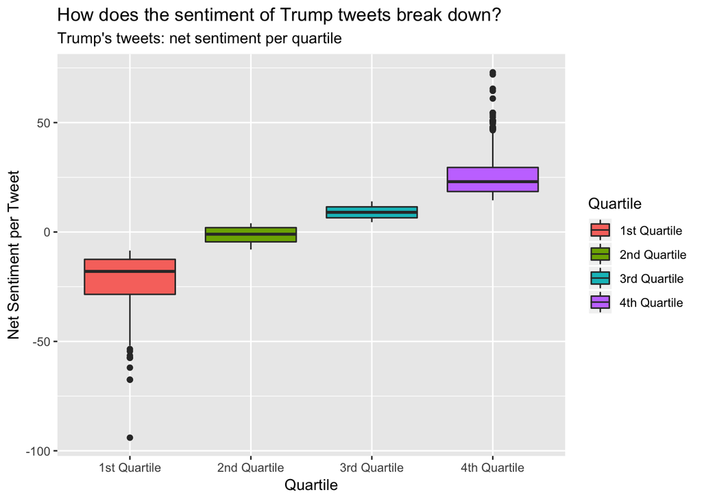

If we break these tweets into quartiles based on sentiment, we see a clear distinction between the 1st quartile (most negative) and 4th quartile (most positive). Let us count the most common bigrams appearing in both groups. In other words, which words are found most often among the most positive, and most negative, Trump tweets?

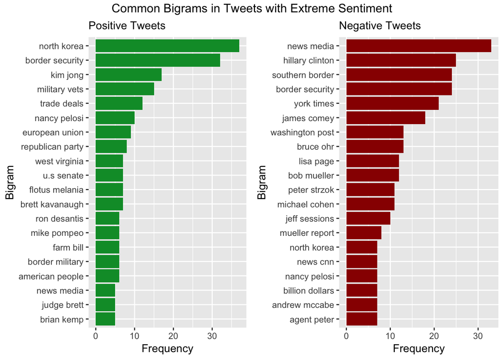

We can see above that “trade deals”, “FLOTUS Melania” and “American people” are more likely to appear among positive tweets, while “Hillary Clinton”, “James Comey” and “Mueller Report” are more likely to appear among the negative tweets. Interestingly, some bigrams, like “North Korea”, “border security”, and “Nancy Pelosi” appear on both lists.

In many cases we find NLP to be an iterative process. For example, now that we know Trump has a strong negative emotion in regards to the Mueller report, we can dig deeper into those tweets that contain the word “mueller” (we find 83 of them).

We can use the NRC lexicon once again to dig deeper into the emotions of these tweets about Mueller.

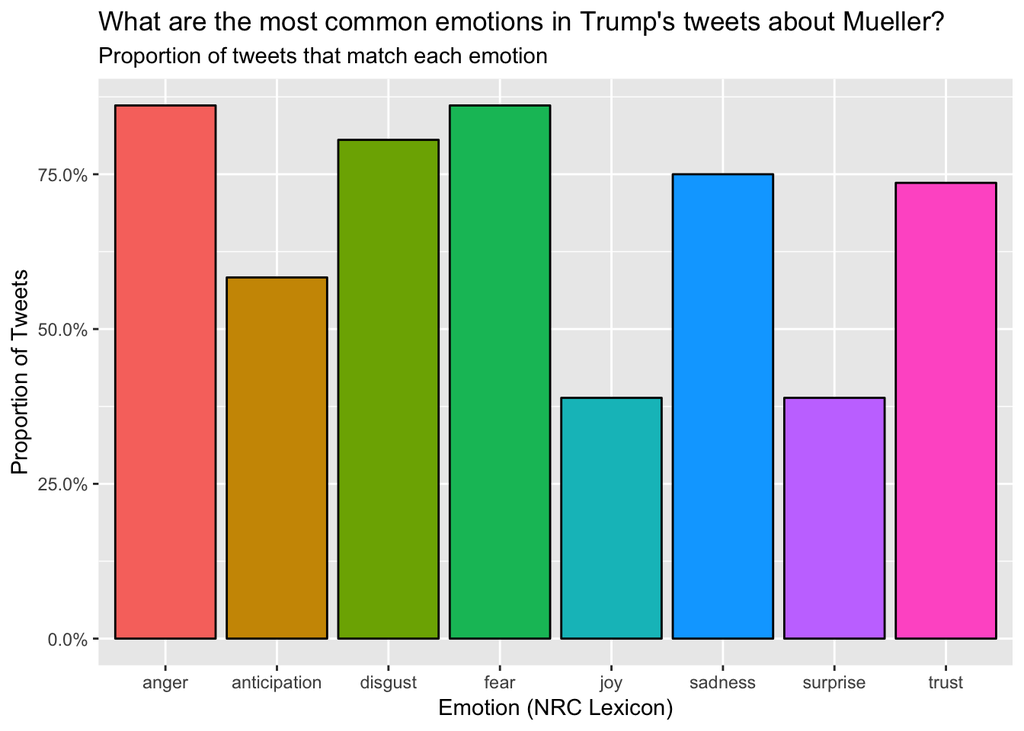

Among this subset we find 86% of tweets correspond to “anger” and “fear”, 81% correspond to “disgust”, and 75% to “sadness”, with very little “joy” or “surprise”. Aside from an oddly high “trust”, this passes a sanity check.

We can look closer, finding the top 20 bigrams in this subset (not including the word “Mueller”):

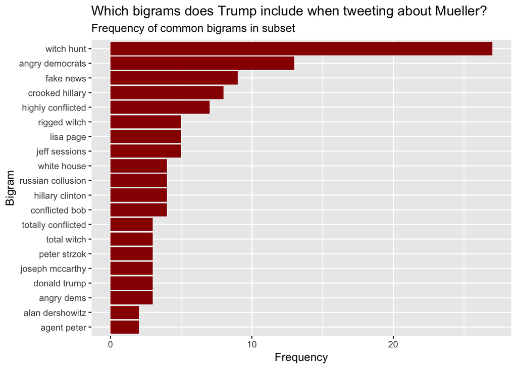

We see phrases like “witch hunt”, “angry Democrats”, “fake news” and “crooked Hillary” rise to the top of the list, which again passes a sanity check. These are the things Trump is likely to talk about when discussing “Mueller” on Twitter.

Instead of using net sentiment, we might focus on a specific emotion from the NRC lexicon, for example: fear.

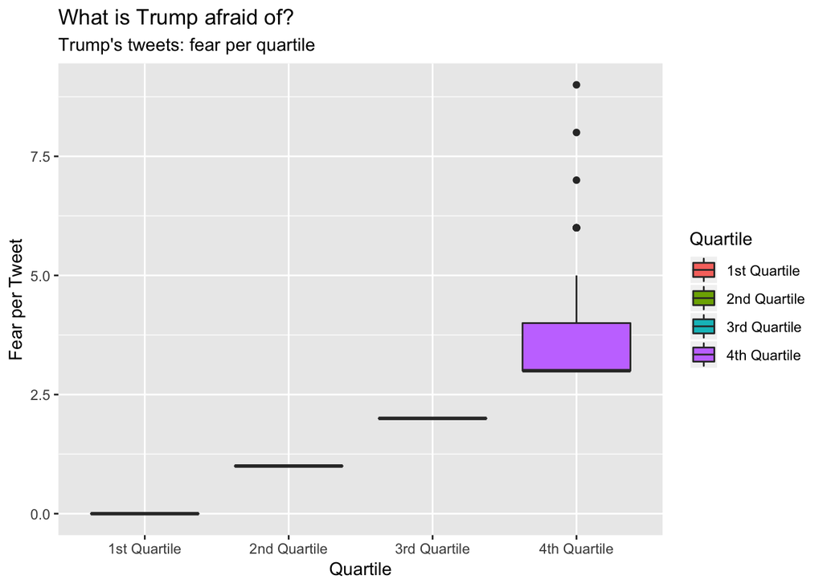

Which bigrams appear most commonly in the 4th Quartile? That is, what are the things Trump fears the most?

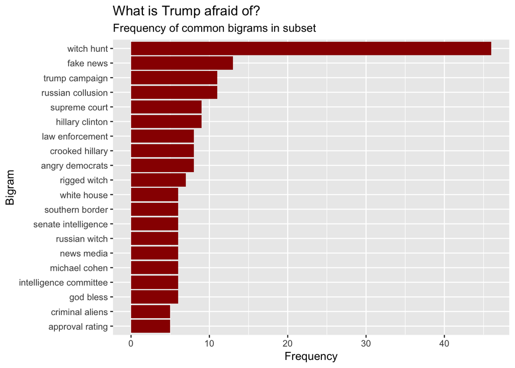

Here we find “witch hunt”, “fake news”, and oddly, “Trump campaign”. And although it may be tempting to claim Trump fears a “Russian witch”, this is just a result of our bigram splitting the phrase “Russian witch hunt” into two pieces.

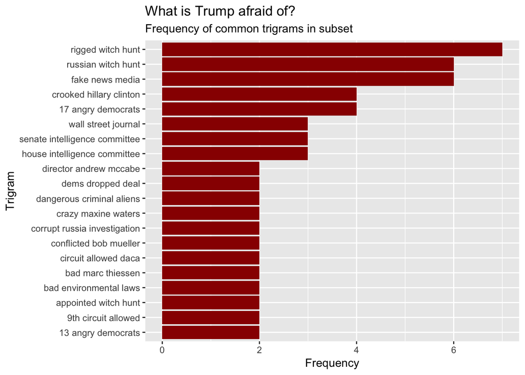

Now that we have a better understanding of what Trump fears, what brings him joy? We can repeat the process as before, looking only at the 4th quartile, tweets with the highest “joy” sentiment.

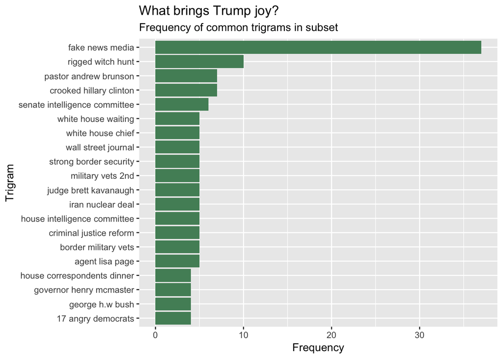

Oddly we find “fake news media”, “rigged witch hunt” and “crooked Hillary Clinton” are among the most common trigrams among the tweets with the highest “joy” sentiment. Should we assume Trump takes joy in criticizing Hillary Clinton and the media? Or is it possible our sentiment lexicon is failing to classify as well as it could?

## Using Sentimentr

Until now, we have been establishing sentiment on a word-by-word basis. The [sentimentr package](https://cran.r-project.org/web/packages/sentimentr/index.html) in R offers a different approach. Unlike our word-based method, sentimentr considers valence shifters. Consider these two examples:

> I don’t like it.

> I really like it.

Both of these sentences include the word “like”.

|  | word | nrc | afinn | bing | loughran | sentiment |
| --- | --- | --- | --- | --- | --- | --- |
| 7460 | like | 0 | 2 | 2.5 | 0 | 4.5 |

This word appears in two of our sentiment lexicons, with a total sentiment score of 4.5. However, reading this as a human, we can see that both “I don’t like it” and “I really like it” have *opposite* sentiments. In this case, the words “don’t” and “really” are more important in determining the true sentiment. In this case, “don’t” and “really” are our valence shifters, which sentimentr considers on a sentence-by-sentence basis.

Since both methods score sentiment on different scales, let us first consider cases where these methods disagree.

Consider the following tweets:

```
## [1] "So disgraceful that the questions concerning the Russian Witch Hunt were leaked to the media. No questions on Collusion. Oh I see...you have a made up phony crime Collusion that never existed and an investigation begun with illegally leaked classified information. Nice!"
```

Our lexicon method scored this tweet -48 (negative), while sentimentr gave it a score near 0 (neutral). Even a human reader may struggle with the sentiment of the above tweet.

```
## [1] "....great people of Montana will not stand for this kind of slander when talking of a great human being. Admiral Jackson is the kind of man that those in Montana would most respect and admire and now for no reason whatsoever his reputation has been shattered. Not fair Tester!"
```

Our lexicon method scored this tweet 39.5 (positive), while sentimentr gave it a score near 0 (neutral). In this case it would appear sentimentr has considered phrases such as “will not stand” and “his reputation has been shattered” to mitigate the positive sentiment of “great people” and “respect and admire”.

In order to better compare these two methods, we will standardize both sentiment scores into a z score, and then look at the difference between them. Under this standardized scale, a score of 0 corresponds to the average sentiment, with negative numbers being more “negative”" than average, and positive numbers being more “positive” than average.

| id_str | sentimentr | sentiment | diff |
| --- | --- | --- | --- |
| 1009900144861634560 | 0.8623054 | 0.4639606 | 0.3983447 |
| 1009900306694656000 | 1.1637520 | 1.1978241 | -0.0340720 |
| 1009900449456115712 | 1.7299817 | 1.6598862 | 0.0700955 |
| 1009916650622251008 | -1.1472069 | -0.9765861 | -0.1706208 |
| 1009928980475138048 | 0.2193424 | 0.1377991 | 0.0815433 |
| 1009935968164630528 | -0.2130743 | -0.0252817 | -0.1877927 |

Consider the following tweets:

```
## [1] "If anybody but your favorite President Donald J. Trump announced that after decimating ISIS in Syria we were going to bring our troops back home (happy & healthy) that person would be the most popular hero in America. With me hit hard instead by the Fake News Media. Crazy!"
```

The standardized lexicon method scored this 1.23 (above average), while sentimentr scored this -1.1 (below average). Unlike the lexicon method, sentimentr balances the positivity of “bring our troops back home (happy & healthy)” with “hit hard instead by the Fake News Media”.

```
## [1] "Collusion is not a crime but that doesn't matter because there was No Collusion (except by Crooked Hillary and the Democrats)!"
```

The standardized lexicon method scored this -1.71 (below average), while sentimentr scored this 1.15 (above average). Which sentiment do you agree with?

```
## [1] "Patrick Moore co-founder of Greenpeace: The whole climate crisis is not only Fake News it's Fake Science. There is no climate crisis there's weather and climate all around the world and in fact carbon dioxide is the main building block of all life. @foxandfriends  Wow!"
```

The standardized lexicon method scored this -1.68 (below average), while sentimentr scored this 1.26 (above average). Sentimentr thinks Trump was expressing a positive sentiment here, which makes sense if we assume the denial of climate change is a positive thing for Trump’s agenda.

If we look at the common bigrams in our 1st quartile versus our 4th quartile based on sentimentr score, we end up with something similar to what we saw before.

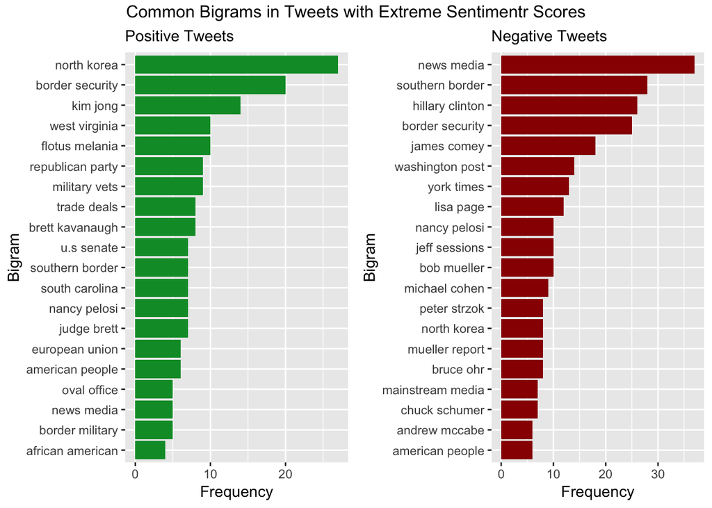

Although the value of including valence shifters may not be immediately obvious in the above examples, looking at the big picture, we can usually expect a more reasonable sentiment score by considering them. Consider these examples:

| id | text | sentimentr_score | lexicon_score |
| --- | --- | --- | --- |
| 1 | I love Trump. | 0.3752777 | 10.5 |
| 2 | I don’t love Trump. | -0.3250000 | 10.5 |
| 3 | I hate Trump. | -0.4907477 | -5.5 |
| 4 | I don’t hate Trump. | 0.4250000 | -5.5 |

Our lexicon method fails to see the difference between these sentences; sentimentr understands context that a word-based dictionary match never will.

## Conclusion

As with all forms of unsupervised learning, when it comes to using natural language processing to extract sentiment, there is no official “right answer”. Ultimately it comes down to the judgement and experience of the people assigned to the project. To any project manager, or researcher trying to replicate results, this can be equal parts frustrating and exiliarating. There is a lot of fun to be had at the edge of theory and application.

Despite these limitations, sentiment analysis is a critical skill for anyone working with NLP. The tidytext package in R, and sentimentr package, make it super easy to get a working prototype together in a few hours. Help yourself to our code, and have fun psychoanalyzing the President’s tweets for yourself.

## Shameless Plug

Are you a Data Analyst, Data Scientist, Data Engineer, Machine Learning Engineer or Machine Learning Researcher looking to advance your career? [Check out DataJenius today](https://datajenius.com). We search through millions of listings on Indeed, Monster, ZipRecruiter and other job sites to find those most relevant to data professionals. Not sure where you fit in this rapidly changing industry? Our self assessment will help match your skills to the job roles most suited for you.